# Bikes Share (Capstone)

# Personal Background

During my job-search and some downtime I started the Google Data Analytics Certificate, more or less for fun, so here is the fictional capstone project. The whole data and scripts can be found [here](https://github.com/SRSteinkamp/rideshare_analystcert)

# Report on Bicycle Usage by Members and Non-Members

## Goal

Use bike usage data to inform the marketing team on how to lead to a better conversion from casual users to annual members.

Questions that needs to be addressed:

- Are there different usage patterns, do casual members use bikes more on weekdays or weekends?
- How are bikes used (round-trip or one-way)?
- Do casual and annual members differ in terms of trip-durations?

## Data Sources

The data has been provided by divvy bikes [here](https://divvy-tripdata.s3.amazonaws.com/index.html), under [this](https://www.divvybikes.com/data-license-agreement) license.

The data is not connected to the fictional company the report is for, but let’s pretend it is. Data description in the capstone protocol are outdated, so certain questions cannot be addressed as for example individual identifiers have been removed over time.

Furthermore, usage patterns of the last 12 months (which are the most actual) might not represent actual use, due to the COVID-19 pandemic.

Possible changes due to the pandemic:

- Lockdowns (i.e. less bike use)
- Higher use of bikes, to avoid public transportation

To not save the data in the repository, I have written a small bash script (`getdata.sh`) to create the `data` folder and download the monthly `.csv` files from the resource into it. Data from April 2020 to April 2021 will be retrieved.

The `data` folder will also be used to store cleaned and aggregate data files.

## Data Preprocessing

I downloaded the monthly files, so we need to get a quick overlook over the columns and structures and, if necessary adapt column names etc.

To make the whole calculation a bit more efficient, I am already transforming dates to datetime and drop a few unneeded columns.

Additionally, I am also creating summary tables for each month to have a few consistency checks.

```r
files = dir(path="data/", pattern = glob2rx("20*.csv"))

dataframes = list()
controls = list()

c <- 1

for (fname in files){
    print(fname)
    # All ready reduce the amount of data in the loaded data, to keep things clean,
    # for validation also change dates to datetime
    dataframes[[c]] <- fread(paste('data/', fname, sep=''), sep=',',
                             select=c('ride_id', 'started_at', 'ended_at', 'member_casual',
                                      'start_station_name', 'end_station_name')) %>%
        mutate(started_at = as_datetime(started_at), ended_at = as_datetime(ended_at))

    # Do some consistency checks
    controls[[c]] <- summarise(dataframes[[c]], min_s = min(started_at), max_s = max(started_at),
                                     min_e = min(ended_at), max_e = max(ended_at),
                                     member = n_distinct(member_casual),
                                     stations = n_distinct(start_station_name),
                                     n = n())
    c <- c + 1
}
```

```r
bind_rows(controls)
```

[output not shown]

```r
# Combine data and save, so we can load a single df.
whole <- bind_rows(dataframes)
write_csv(whole, 'data/wholedata.csv')
```

```r
# Now do a few calculations, which we will need for further uses and analysis.

data <- whole %>%
  mutate(month = month(started_at, label=TRUE),
         date = date(started_at),
         day = day(started_at),
         year = year(started_at),
         day_of_week = wday(whole$started_at, label=TRUE),
         start_station_name = as.character(start_station_name),
         end_station_name = as.character(end_station_name))

data$tripduration <- as.numeric(difftime(whole$ended_at, whole$started_at))
data$samestation <- data$start_station_name == data$end_station_name
```

Now, also given the data, a bit of data cleaning has still to be performed. There are negative values, and a few very, very long times (let’s keep them in first).

```
The data has been processed to remove trips that are taken by staff as they service and inspect the system; and any trips that were below 60 seconds in length (potentially false starts or users trying to re-dock a bike to ensure it was secure).
```

But according to the new information, we do not need to remove service trips, so there appears to be some data cleaning which had already been done.

Unfortunately - there are still some testing stations in there, which will now be removed.

```r
# Remove negative trips and testing stations (as well as missing data)
test_stations <- c("hubbard_test_lws", "WATSON TESTING - DIVVY", "",
                   "HUBBARD ST BIKE CHECKING (LBS-WH-TEST)")
data_clean <- filter(data, tripduration > 60) %>%
  filter(! start_station_name %in% test_stations,
         !end_station_name %in% test_stations)

write_csv(data_clean, 'data/clean_data.csv')
```

## Analysis and Visualization

```r
# Read data directly, to save time.
data <- fread('data/clean_data.csv')
```

To keep this project a bit more simple, I will summarize the data in terms of descriptive statistics and rely on simple generalized linear models to come to conclusions.

### First show a summary of the data

```r
summary(data %>%
          select(member_casual, month, day_of_week, tripduration, samestation) %>%
          mutate(tripduration = tripduration / 60))
```

[output not shown]

### Statistical analysis

The first question I want to address here is whether week-days and membership status have a significant influence on trip duration.

```r
data <- mutate(data, tripduration_min = tripduration / 60)

tripduration_model <- glm(tripduration_min ~ day_of_week * member_casual, data=data)

summ(tripduration_model)
```

```
MODEL INFO:
Observations: 3535941
Dependent Variable: tripduration_min
Type: Linear regression

MODEL FIT:
χ²(13) = 693803591.94, p = 0.00
Pseudo-R² (Cragg-Uhler) = 0.00
Pseudo-R² (McFadden) = 0.00
AIC = 48466417.58, BIC = 48466613.75

Standard errors: MLE
-----------------------------------------------------------------------
                                            Est.   S.E.   t val.      p
--------------------------------------- -------- ------ -------- ------
(Intercept)                                40.84   0.59    69.56   0.00
day_of_weekDo                               0.78   0.81     0.95   0.34
day_of_weekFr                               1.50   0.77     1.96   0.05
day_of_weekMi                              -1.23   0.82    -1.49   0.14
day_of_weekMo                               3.20   0.83     3.86   0.00
day_of_weekSa                               5.00   0.71     7.08   0.00
day_of_weekSo                               8.28   0.73    11.27   0.00
member_casualmember                       -25.76   0.72   -35.57   0.00
day_of_weekDo:member_casualmember          -0.80   1.01    -0.80   0.43
day_of_weekFr:member_casualmember          -1.03   0.97    -1.06   0.29
day_of_weekMi:member_casualmember           1.18   1.02     1.17   0.24
day_of_weekMo:member_casualmember          -3.07   1.03    -2.99   0.00
day_of_weekSa:member_casualmember          -2.26   0.92    -2.46   0.01
day_of_weekSo:member_casualmember          -5.39   0.96    -5.63   0.00
-----------------------------------------------------------------------

Estimated dispersion parameter = 52518.1
```

For the analysis of round trips versus one way trips, I will rely on summary statistics.

```r
data %>%
  group_by(member_casual, day_of_week) %>%
  summarise(Proportion = round(mean(samestation) * 100, 2))
```

[output not shown]

```r
data %>%
  group_by(member_casual, samestation) %>%
  summarise("Median Tripduration" = median(tripduration_min))
```

[output not shown]

Finally, let’s look at differences in riding behavior.

```r
data %>%
  group_by(member_casual, day_of_week) %>%
  summarise(n = n()) %>%
  mutate(Proportion = round(100 * (n / sum(n)), 2))
```

| member_casual | day_of_week | n | Proportion |
| --- | --- | --- | --- |
| casual | Di | 152342 | 10.48 |
| casual | Do | 164782 | 11.34 |
| casual | Fr | 213923 | 14.72 |
| casual | Mi | 156889 | 10.79 |
| casual | Mo | 154279 | 10.61 |
| casual | Sa | 341103 | 23.47 |
| casual | So | 270285 | 18.59 |
| member | Di | 292195 | 14.03 |
| member | Do | 304022 | 14.60 |
| member | Fr | 315898 | 15.17 |

[output cut: 4 more lines]

Here we also see a trend in that casual riders use bikes more often on the weekends, whereas members do not appear to have strong differences in weekly riding.

# Report / Conclusions

## Our population:

[figure not shown]

First of all, we see that in the last 12 months, there have been many more rides by members than by casual users.

However, due to data privacy, we cannot say how many riders we have so this dataset is incomplete in this regard.

## Rides during the Week

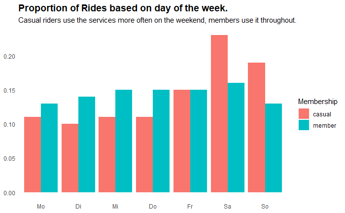

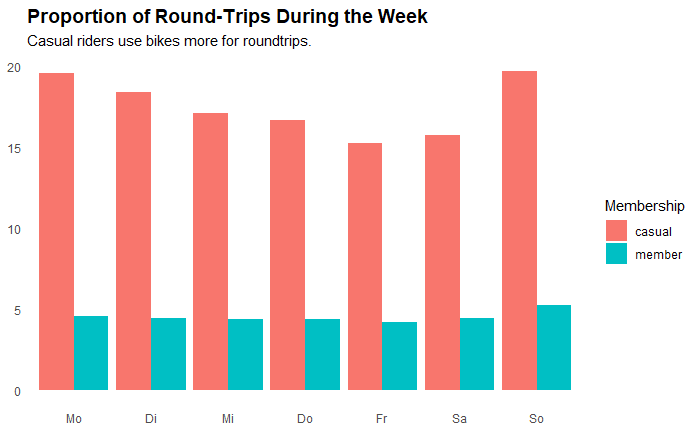

Further interesting observations in terms of biking behavior are:

- Casual members use bikes more often on the weekends
- Members use bikes throughout the week
- Casual members use bikes more often for round trips
- Members do one-way trips

## Trip durations

[figure not shown]

The graphic shows, also referring to our GLM analysis above, that casual rides do longer rides and that rides during the weekend are generally longer.

# Conclusion and Advice

In my opinion given the data and having some experience in using bike-shares, I think the marketing team could consider the following three points to convert casual riders to annual riders:

- Cater to the great network of stations and explain that using bikes for shorter trips is definitely worth it. As a member you do not need to carry your bike with you all day, you can change it just like that.
- Especially during the pandemic: The network of bike stations is a healthier alternative to public transportation. It can also be used for the customers commute.
- More generally: Stress that an annual subscription is cheaper and reduces stress, as you can always chose a bike, whererver you want and do your next trip with it - Not only on the weekend but also for commutes or grocery shopping during the week.